# Random Variable Generation using Quantile Transformation

September 10, 2018

## Inverse CDF Transformation

- \(X\) random variable, PDF of \(X\) is \(f(x)\): \(X \sim p(x)\).
- Cumulative density function CDF: \(F(x) = \int_{-\infty}^{x} p(s) ds\)
- IF \(F\) is invertible, \(Y = F^{-1}(U)\) will have the same distribution as \(X\).
- This is called Inverse CDF/ Quantile/ Probability-Integral transformation.

## First Example:

- PDF of a logistic random variable. \[ f(x \mid \lambda) = \frac{\lambda e^{-\lambda x}}{\{1+e^{-\lambda x} \}^2} \]
- Hence the CDF can be written as: \[ F(x \mid \lambda) = \frac{1}{\{1+e^{-\lambda x} \}} \]
- How do we generate samples from logistic?
- Generate \(U \sim U[0,1]\), and apply \(F^{-1}(U)\) as above.

## First Example Continued

```r
set.seed(123)
logistic_rvgen <- function(lamb,n=1){
    # Recall the signature for runif(n,high,low)
    u=runif(n)
    x=-log((1/u)-1)/lamb
    return(x)
}
```

## Visualize the samples

- Let us generate 10000 random variables from the logistic distribution

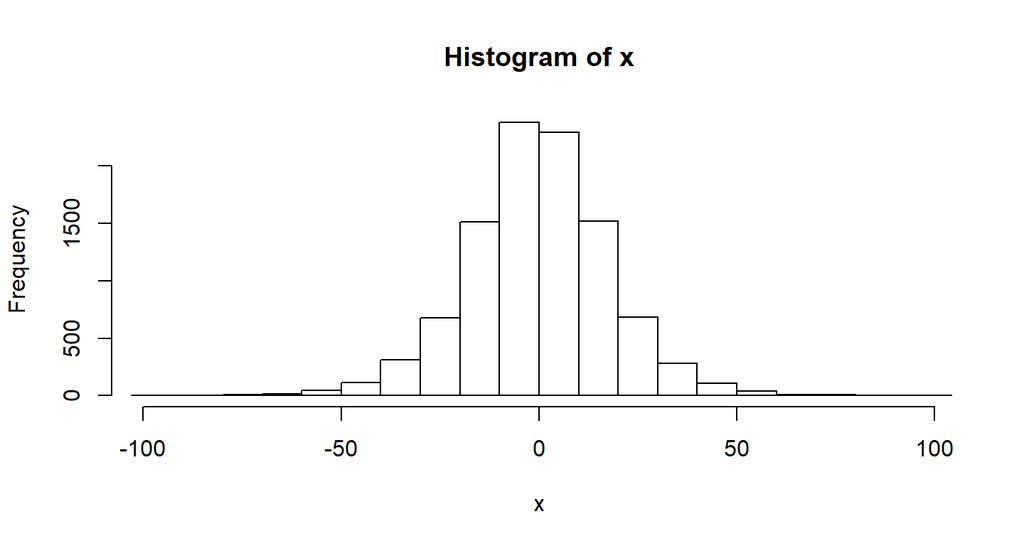

```r
lamb=0.1
n=10000
x=logistic_rvgen(lamb, n)
hist(x)
lines(density(x))
```

## Verify that we are correct

- We can verify that we are correct by drawing the density along with the histogram.

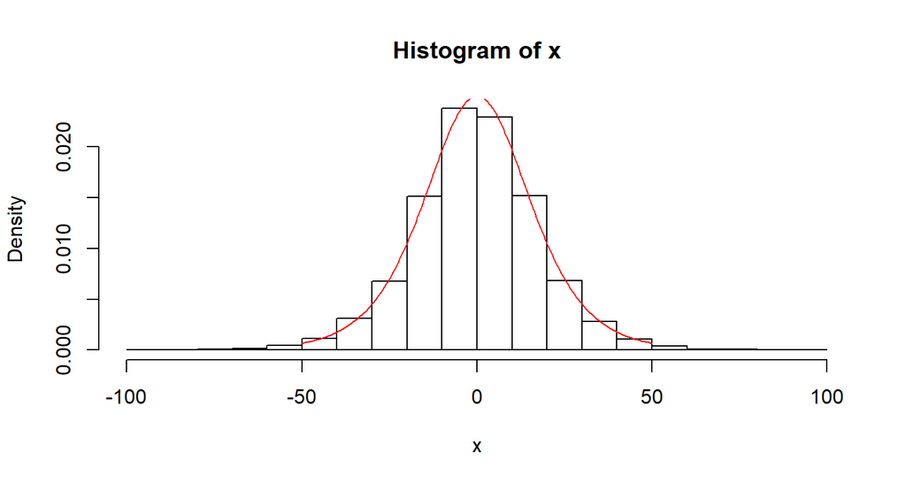

```r
y=seq(-50,50,0.5)
fy=lamb*exp(-lamb*y)/((1.0+exp(-lamb*y))^2)
hist(x, freq  = F)
lines(y,fy, col = "red")
```

## Second Example - Exponential

- PDF: \(f(x) = \lambda e^{-\lambda x}, \; x \ge 0, \lambda > 0\).
- CDF: \(F(x) = 1 - e^{-\lambda x}, \; \lambda > 0\).
- Inverse Transformation: \(F^{-1}(u) = -\frac{1}{\lambda}\log(1-u)\), \(u \sim U(0,1)\).

## Second Example - Exponential

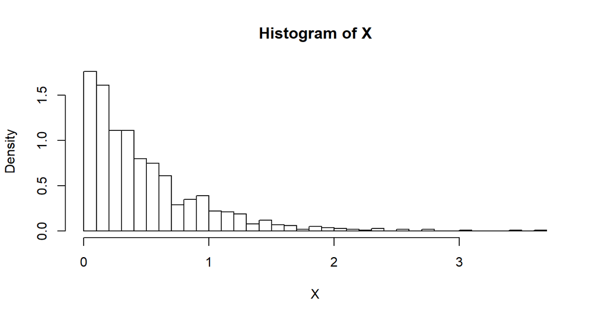

```r
n = 1e3
lambda = 2
U = runif(n)
X = - 1/lambda*log(U)
hist(X, breaks = 30, freq=F)
```

## Verify that we are correct

- We can verify that we are correct by drawing the density along with the histogram.

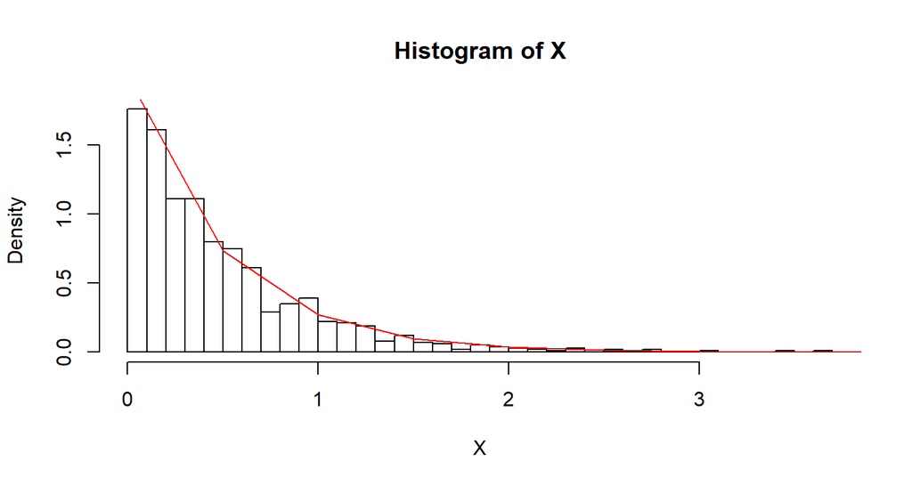

```r
Y=seq(0,50,0.5)
fy=lambda*exp(-lambda*Y)
hist(X, breaks = 30, freq  = F)
lines(Y,fy, col = "red")
```

## Box-Mueller

- Let's do the Box-Mueller transformation
- We generate two normal random variable \(X_1\) and \(X_2\) by: \[ U_1, U_2 \sim Unif[0,1] \\ X_1 = \sqrt{-2 \log(U_1)}cos(2 \pi U_2)\\ X_2 = \sqrt{-2 \log(U_1)}sin(2 \pi U_2) \]

## In R

```r
u1 = runif(n)
u2 = runif(n)
x1 = sqrt(-2*log(u1))*cos(2*pi*u2)
x2 = sqrt(-2*log(u1))*sin(2*pi*u2)
x = c(x1,x2)
```

## Plotting

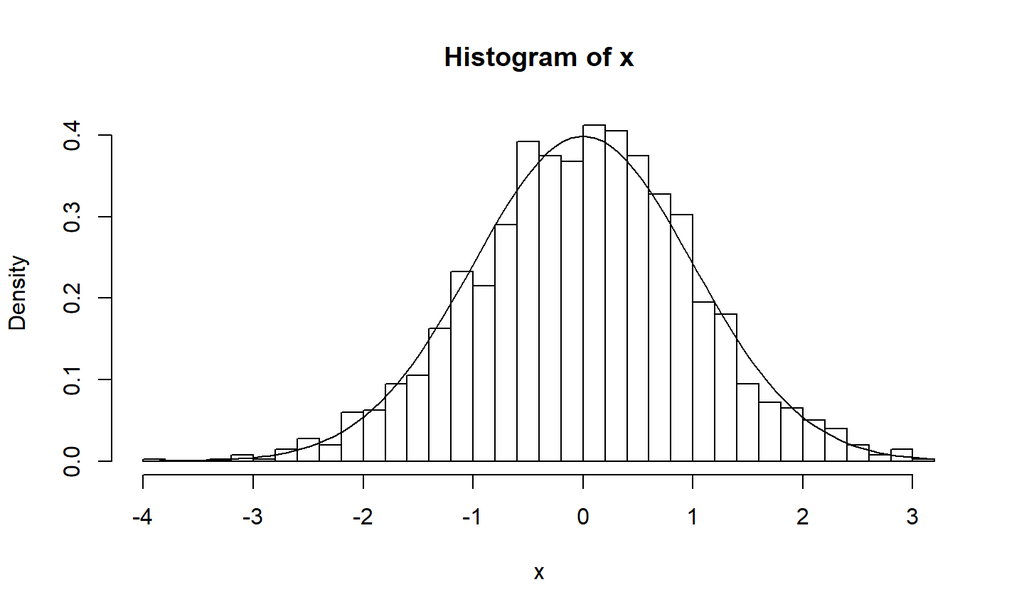

```r
hist(x,breaks = 30, freq = F)
curve(dnorm,add=T)
```

- Do you know another visual test for normality?

## QQ plots

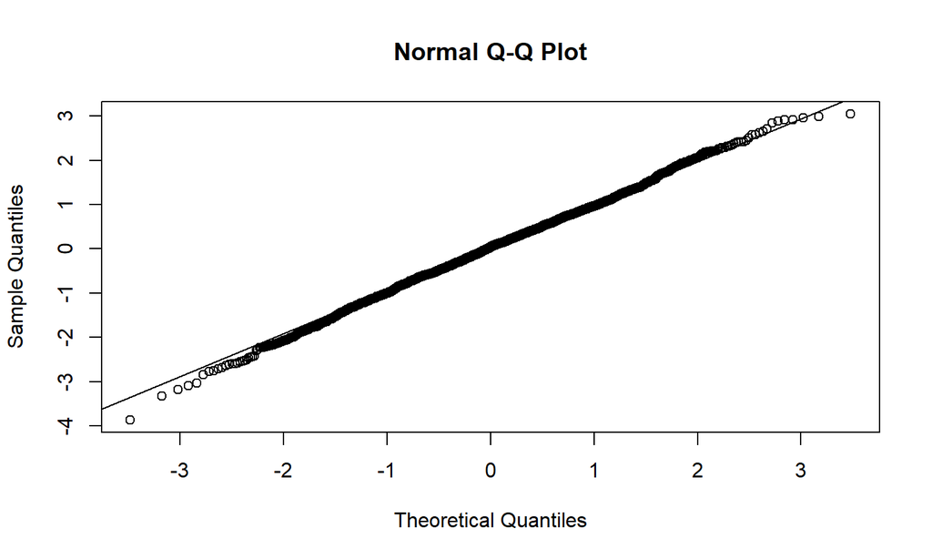

```r
qqnorm(x)
qqline(x)
```

## Homework (will be added to HW 2)

- Write a sampler to generate samples from the following density using the inverse transform.

\[ p(x) = \frac{\alpha \beta^{\alpha}}{x^{\alpha + 1}} \text{for } x \ge \beta \]

## Generating from the Uniform disk

- We want to generate samples from the Uniform disk in \(\mathbb{R}^2\). \[ p(x,y) = 1/\pi \text{ if } x^2 + y^2 \le 1 \]

## Naive Idea

- Generate \(R \sim \text{Unif}[0,1]\) and \(\theta \sim \text{Unif}[0,2\pi]\).
- Set:

\[ X_1 = R \cos(\theta) \\ X_2 = R \sin(\theta) \] - The naive idea does not work.

## Naive Idea in R

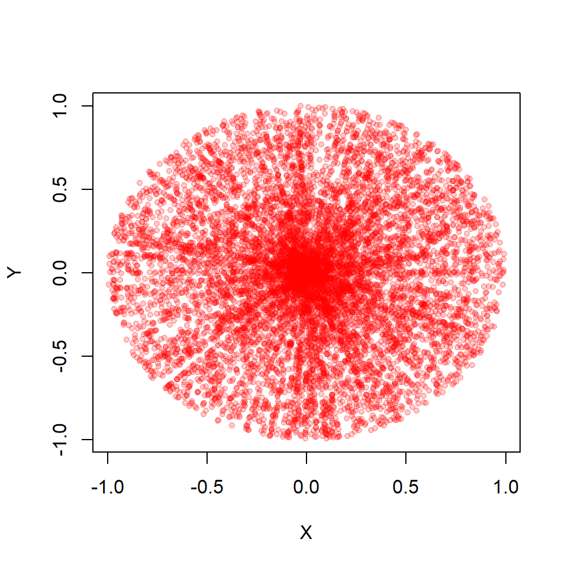

```r
R = runif(1e4,0,1)
theta = 2*pi*runif(1e3,0,1)
X = R*cos(theta);Y = R*sin(theta)
plot(X,Y, pch = 20, col=rgb(1,0,0,0.2))
```

- Thickly concentrated in the center !

## What works

- Generate \(R \sim \text{Unif}[0,1]\) and \(\theta \sim \text{Unif}[0,2\pi]\).
- Set:

\[ X_1 = \sqrt{R} \cos(\theta) \\ X_2 = \sqrt{R} \sin(\theta) \]

## Extra Credit: Why does this work?

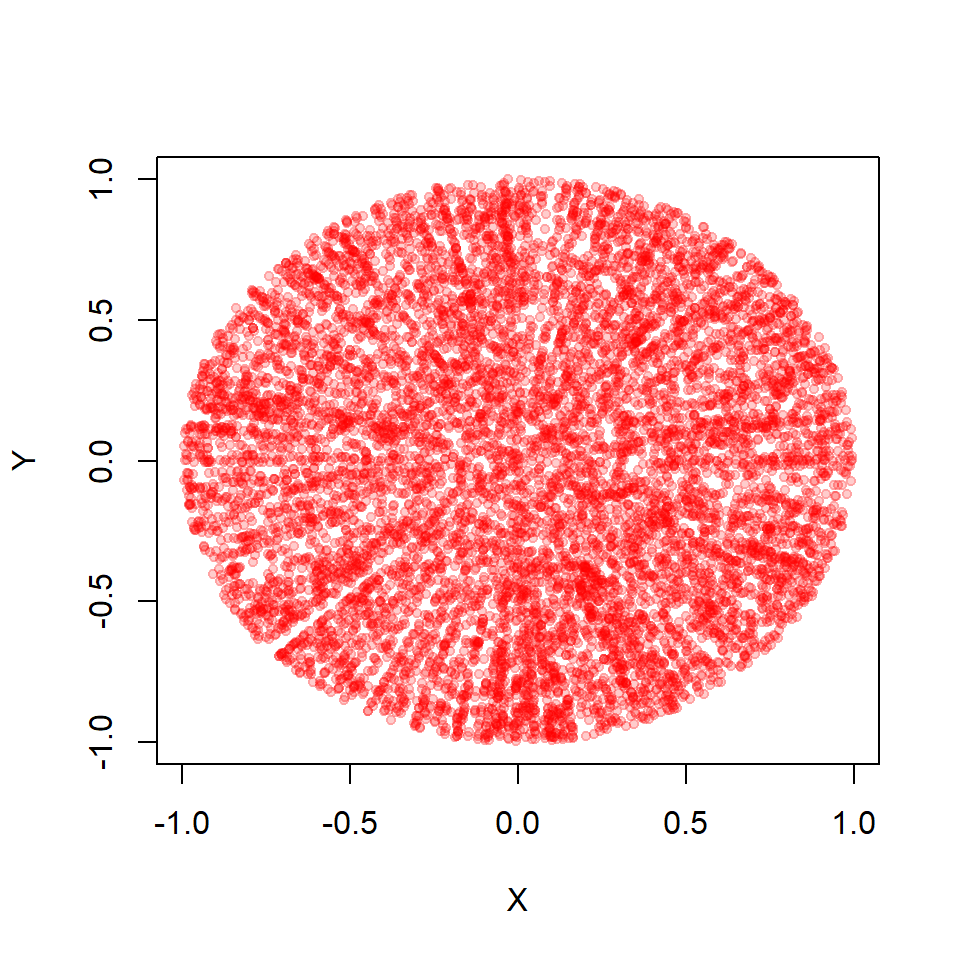

```r
X = sqrt(R)*cos(theta);Y = sqrt(R)*sin(theta)
plot(X,Y,pch = 20, col=rgb(1,0,0,0.2))
```